# HOCR Slides

May 16, 2016

## Crash Course in Rowing Terms

Coxed Boats

- 4+
- 8+

Uncoxed Boats

- Single
- Double
- Quad

## Splits

The 500m split

- shown in erg output
- 1:50 means "You are rowing 500 meters every 1 min and 50 seconds"
- standardizes the concept of average work

## The Head of the Charles

The largest regatta in the world

- 10,234 Rowers
- 25 Countries
- 781 Clubs

4800 meter "Head" Race

- boats are staggered by seed position
- Serpantine race course
- Bridges cuase bottlenecking

## What countries are the Competitors from?

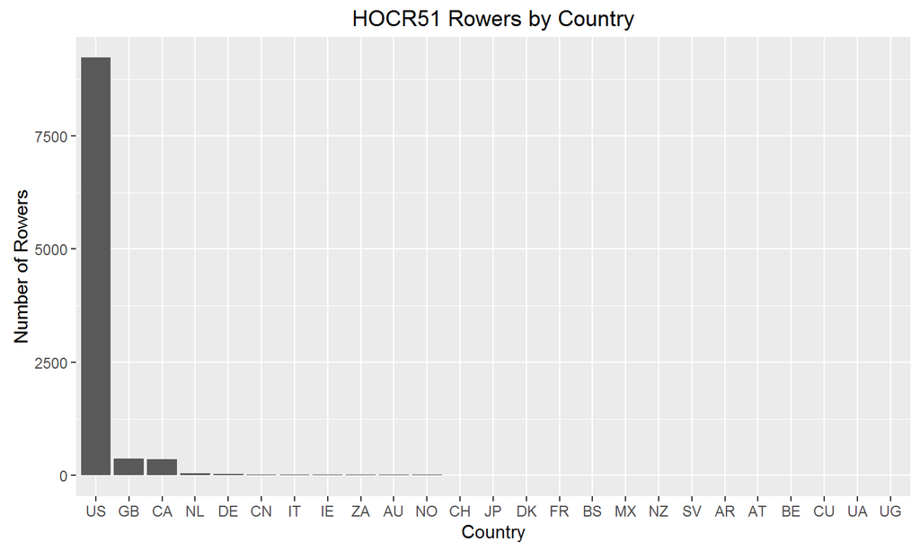

## What States are Represented?

[interactive chart not shown]

## What Cities are Represented?

[interactive chart not shown]

## Research Questions

From the persepctive of a coach:

1. What races are the most competitive?
2. How Should I tell my Coxswain to Row the Course?
3. How Should I tell my rowers to row the course?

## The Coefficient of Variation

\[CV = \frac{\sigma}{\mu}\]

- CV = Stnd.dev / Average
- "standardizes" the standard deviation
- Good measure of relative dispersion/ congestion

## 1. What Races are the most competitive

[interactive chart not shown]

## Competitiveness for Men's events

[interactive chart not shown]

## Competitiveness for Women's events

[interactive chart not shown]

## 2. Penalties

[interactive chart not shown]

## The Course

[interactive chart not shown]

## The Course

[interactive chart not shown]

## Penalty Types

Coxed boats only recieved three types of penalties

1. Buoy Violations
2. Arch Violations
3. Interference/ Failure to yield

## Where do Penalties Happen?

[interactive chart not shown]

## 3. Houw Should I Tell my Rowers to Row the Course?

Concepts to consider:

1. negative splitting
2. passing
3. bottlenecks

## How do most boats row the course?

[interactive chart not shown]

## The Big Turn

Starboards, up Pressure

1. Hawthorn St. to Belmont Hill Boat House
2. A good line is key
3. Lots of variation in times
4. Ability to pass boats is limited

## How did Midd do?

The Men

[interactive chart not shown]

## How did Midd do?

[interactive chart not shown]

## How did Midd do?

The Women

[interactive chart not shown]

## How did Midd Do?

[interactive chart not shown]